# Linear Regression in R for Engineers and Geoscientists

### Michael Pyrcz, Associate Professor, University of Texas at Austin

#### Load the required libraries

We load the plyr package by Hadley Wickham for data manipulation.

#### Load the required libraries

The linear regression method is built into the main R library (I may not have said that right, surfice it to say you won’t have to install nor include it). We include the $plyr$ package as it is convenient for manipulating data.

```r
library(plyr)                                  # data operations by Hadley Wickham
```

If you get an error, you may have to first go to “Tools/Install Packages…” to install these packages. Just type in the names one at a time into the package field and install. The package names should autocomplete (helping you make sure you got the right package name), and the install process is automatic, with the possibility of installing other required dependency packages.

#### Set the working directory

I always like to do this so I don’t lose files and to simplify subsequent read and writes (avoid including the full address).

```r
setwd("C:/PGE337")
```

You will have to change this on Mac. If stuck consider using the GUI to set the working directory. Go to Files/More/Set As Working Directory in the files pane to the right.

#### Read the data table

Copy the NonlinearPor_Perm_data.csv comma delimited 2 well datafile from https://github.com/GeostatsGuy/GeoDataSets to your working directory.

```r
mydata = read.csv("NonlinearPor_Perm_data.csv") # read csv file
```

Let’s visualize the first several rows of our data so we can make sure we successfully loaded it

```r
head(mydata)                                   # preview first several rows in the console
```

```
##   PorosityA PermeabilityA PorosityB PermeabilityB
## 1      16.0         435.0      10.0         101.9
## 2      19.7         543.0       9.1          86.1
## 3      17.0         342.0       9.6         103.0
## 4      19.1         761.0      14.6         243.5
## 5      11.1         170.3      12.9         159.0
## 6      13.9         171.4      11.8         126.4
```

The columns are variables with variable names at the top and the rows are samples

#### Data checking

We’ll extract the variables of interest from the data table into a new vectors for Well B. Afterwards, you are welcome to try linear regression with Well A also. Spoiler alert: the model fit will not be as good.

```r
porB <- mydata$PorosityB                       # make a new vector of PorosityB
permB <- mydata$PermeabilityB                  # make a new vector of PemreabilityB
lnpermB <- log(mydata$PermeabilityB)           # make a new vector of Natural Log of the PermeabilityB
```

```r
par(mfrow=c(3,2))                              # set up a 3x2 matrix of plots
```

Since we are modeling a relationship between two variables let’s start with scatter plots of Perm and Ln(perm) vs. Porosity for Well B. The question is will our linear model be appropriate to model either of these relationships?

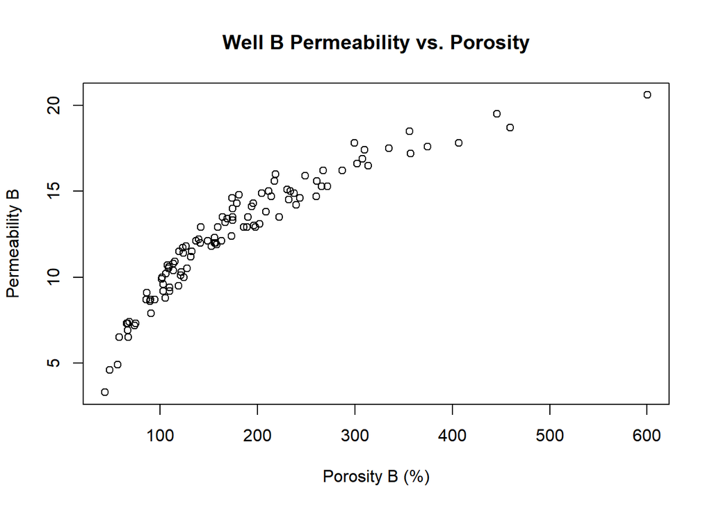

```r
plot(permB,porB,main="Well B Permeability vs. Porosity",xlab=" Porosity B (%) ",ylab=" Permeability B ")
```

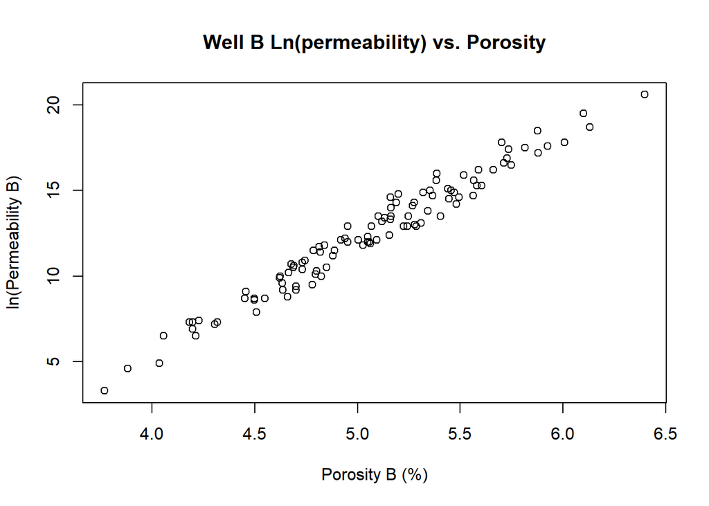

```r
plot(lnpermB,porB,main="Well B Ln(permeability) vs. Porosity",xlab=" Porosity B (%) ",ylab=" ln(Permeability B) ")
```

From these scatter plots it is clear that we should build a linear model of ln(Perm) predicted from Porosity, since the natural log of permeability results in a nice and linear relationship with porosity. Now let’s check the ln(permeability) and porosity distributions.

First, let’s check the porosity frequence histogram and cumulative density function.

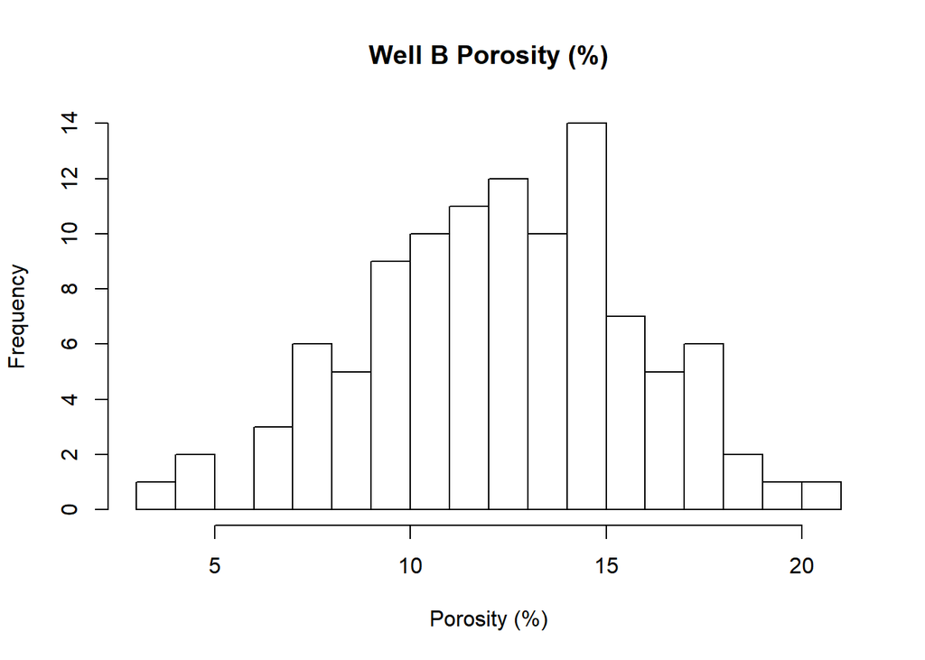

```r
hist(porB,main="Well B Porosity (%)",xlab="Porosity (%)",nclass = 15) # histogram
```

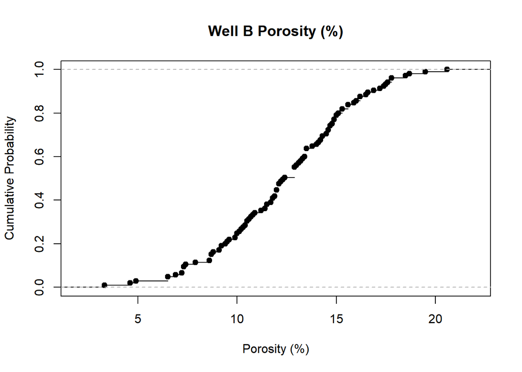

```r
plot(ecdf(porB),main="Well B Porosity (%)",xlab="Porosity (%)",ylab="Cumulative Probability") # CDF
```

We can also look at the summary statistics.

```r
summary(porB)
```

```
##    Min. 1st Qu.  Median    Mean 3rd Qu.    Max.
##    3.30   10.10   12.40   12.42   14.80   20.60
```

Now, let’s look at the porosity frequence histogram and cumulative density function of natural log of permeability.

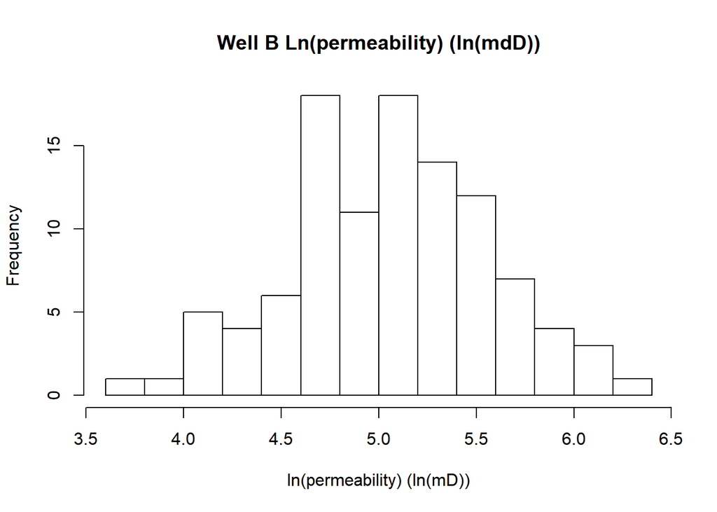

```r
hist(lnpermB,main="Well B Ln(permeability) (ln(mdD))",xlab="ln(permeability) (ln(mD))",nclass = 15) # histogram
```

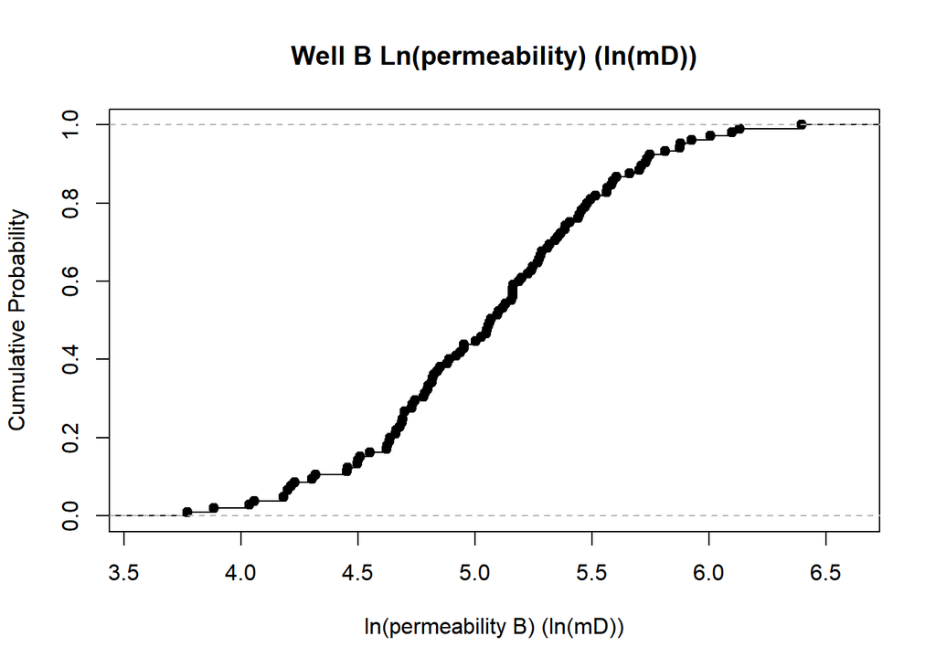

```r
plot(ecdf(lnpermB),main="Well B Ln(permeability) (ln(mD))",xlab="ln(permeability B) (ln(mD))",ylab="Cumulative Probability") # CDF
```

Once again We can also look at the summary statistics.

```r
summary(lnpermB)
```

```
##    Min. 1st Qu.  Median    Mean 3rd Qu.    Max.
##   3.768   4.700   5.069   5.056   5.404   6.397
```

It is always a good idea to check the minimum and maximum for realistic value ranges, for outliers and the shape of the distribution for missing values and / or mixing of populations. The data looks good we can proceed with modeling.

#### Make a concise data table

We’ll extract the variables of interest from the data table into a new concise data table. This is a good method to avoid mistakes like using the wrong data columns. All we need is Well B porosity and natural log of permeability.

Here we make a new data table with just our 2 variables of interest.

```r
WellB <- data.frame(cbind(porB,lnpermB))       # command makes a new datafram combining our 2 vectors
```

Let’s look at the new, concise table.

```r
head(WellB)
```

```
##   porB  lnpermB
## 1 10.0 4.623992
## 2  9.1 4.455509
## 3  9.6 4.634729
## 4 14.6 5.495117
## 5 12.9 5.068904
## 6 11.8 4.839451
```

Once again, we can check the summary statistics.

```r
summary(WellB)
```

```
##       porB          lnpermB
##  Min.   : 3.30   Min.   :3.768
##  1st Qu.:10.10   1st Qu.:4.700
##  Median :12.40   Median :5.069
##  Mean   :12.42   Mean   :5.056
##  3rd Qu.:14.80   3rd Qu.:5.404
##  Max.   :20.60   Max.   :6.397
```

#### Build the Linear Regression Model Object

Now we are ready to calculate a linear regression model to predict ln(permeability) from porosity for Well B.

```r
lnpermB.lm = lm(lnpermB ~ porB,data=WellB)     # our linear model predicts lmpermB from porB
```

To see the resulting model coefficients use this command.

```r
print(lnpermB.lm)                              # model coefficients
```

```
##
## Call:
## lm(formula = lnpermB ~ porB, data = WellB)
##
## Coefficients:
## (Intercept)         porB
##      3.2016       0.1493
```

The linear model object (“lnpermB.lm”) is very convenient. It includes all the information we need for hypothesis testing, and confidence and prediction intervals. In fact the hypothesis tests are completed automatically. We can make a summary object that includes the hypothesis test results.

```r
lm.summary = summary(lnpermB.lm, correlation = TRUE) # summary of model
```

#### Model Checking

First let’s check the statistical significance of the model coefficients with the t-test.

```r
print(lm.summary$coefficients)                 # coefficients, t statistic and probability
```

```
##             Estimate  Std. Error  t value     Pr(>|t|)
## (Intercept) 3.201571 0.036406029 87.94068 1.025497e-98
## porB        0.149338 0.002825949 52.84527 1.921276e-76
```

For each coefficient you can observe the estimated model parameter, standard error and resulting t-statistic and the two-tailed probability of >|t-statistic| or the maximum alpha level that one would reject the null hypothesis. As you can see we reject the null hypothesis ($\alpha = 0.05$) that the model coefficients slope (porB) and intercept (intercept) are equal to 0.0. The model coefficients are statistically significant (different than $0.0$).

Now lets look at the f-test for the entire model. We access the f-statistic results with $fstatistic.

```r
print(lm.summary$fstatistic)                   # f statistic results
```

```
##    value    numdf    dendf
## 2792.622    1.000  103.000
```

The f-statistic is calculate from difference in sum of square error between the model and a reduced, constant slope model. We reject the reduced, constant slope model in favour of the full model given $f_{critical}$ calculated given $\alpha = 0.05$, $DF_1 = p - 1 = 1$ and $DF_2 = n-p = 103$ equal to 3.93.

Let’s check the distribution of residuals for bias and outliers. The residual vector is a member of the linear regression model object. We access this vector with $residual.

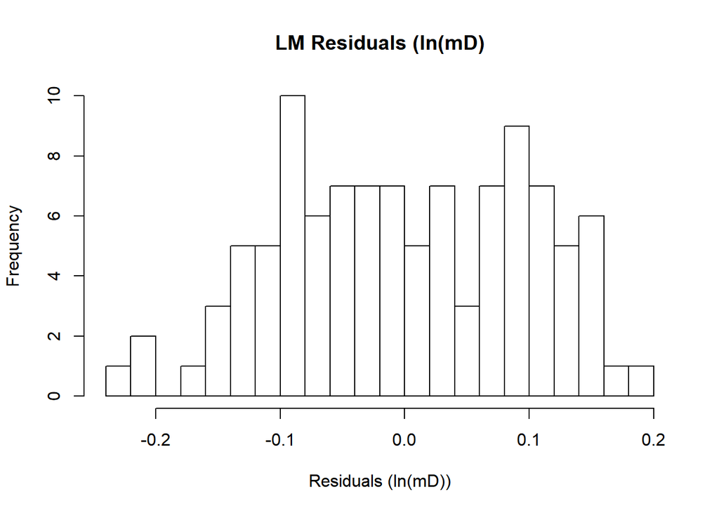

```r
hist(lm.summary$residuals,main="LM Residuals (ln(mD)",xlab="Residuals (ln(mD))",nclass = 15) # histogram
```

```r
summary(lm.summary$residuals)                  # summary statistics for residuals
```

```
##      Min.   1st Qu.    Median      Mean   3rd Qu.      Max.
## -0.222276 -0.081949 -0.001155  0.000000  0.084534  0.186393
```

The residuals look good, the mean = 0.0 and there are no outliers indicating data values with poor prediction accuracy.

One could visualize all this previous output in the console with the summary command.

```r
summary(lnpermB.lm, correlation = TRUE)        # all summary for linear regression model
```

```
##
## Call:
## lm(formula = lnpermB ~ porB, data = WellB)
##
## Residuals:
##       Min        1Q    Median        3Q       Max
## -0.222276 -0.081949 -0.001155  0.084534  0.186393
##
## Coefficients:
##             Estimate Std. Error t value Pr(>|t|)
## (Intercept) 3.201571   0.036406   87.94   <2e-16 ***
## porB        0.149338   0.002826   52.84   <2e-16 ***
## ---
## Signif. codes:  0 '***' 0.001 '**' 0.01 '*' 0.05 '.' 0.1 ' ' 1
##
## Residual standard error: 0.09899 on 103 degrees of freedom
## Multiple R-squared:  0.9644, Adjusted R-squared:  0.9641
## F-statistic:  2793 on 1 and 103 DF,  p-value: < 2.2e-16
##
## Correlation of Coefficients:
##      (Intercept)
## porB -0.96
```

#### Confidence and Prediction Intervals

Let’s get the confidence intervals for the fitted model parameters.

```r
confint(lnpermB.lm,level = 0.95)               # confidence intervals
```

```
##                 2.5 %    97.5 %
## (Intercept) 3.1293680 3.2737735
## porB        0.1437334 0.1549426
```

We get the lower and upper 95% confidence intervals for both intercept and slope.

Let’s demonstrate prediction intervals by calculating them at the data locations. Note the prediction intervals are centered on the model fit.

```r
prediction = predict(lnpermB.lm,interval="predict") # prediction intervals at data locations
head(prediction)
```

```
##        fit      lwr      upr
## 1 4.694951 4.497233 4.892669
## 2 4.560547 4.362419 4.758675
## 3 4.635216 4.437332 4.833100
## 4 5.381906 5.184277 5.579536
## 5 5.128032 4.930761 5.325302
## 6 4.963760 4.766477 5.161042
```

We now have a data table with the model fit and prediction intervals for all of our porosity data.

#### Built-in Diagnostic Plots

Furthermore the linear regression model has built in diagnostic plots that are very useful for checking our model. We produce four plots with a single command. Let’s first declare a 2x2 plot matrix for best viewing and then run the diagnostic command.

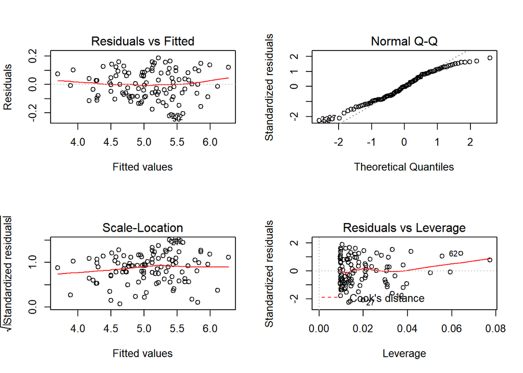

```r
par(mfrow=c(2,2))                              # plot matrix
plot(lnpermB.lm)                               # make built-in diagnostic plots
```

Here’s a summary of each plot: 1. Residual vs Fitted to check linearity and homoscedasticity assumptions. Check for large residuals / biased expectation. 2. Normal Q-Q to check the normality in the residuals assumption. Points should be on the 45 degree line. 3. Scale-Location to check assumption of homoscedasticity. There should not be a pattern. 4. Residual vs. Leverage to identify poorly fit data that have large influence on the model (leverage).

R and Studio are an amazing combination for efficient statistical workflow execution. The linear regression methods shown here are very well documented (see the link at the top). I hope this demonstration has been useful. I’m always happy to discuss,

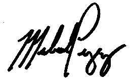

Michael Pyrcz, P.Eng., Ph.D. Associate Professor, the University of Texas at Austin

#### About Michael J. Pyrcz, P.Eng., Ph.D.

Michael Pyrcz is an associate professor at the University of Texas at Austin. He teaches and consults on the practice of geostatistical reservoir modeling and conducts research on new geostatistical methods to improve reservoir modeling and uncertainty for conventional and unconventional reservoirs. He has published over 40 peer reviewed technical articles, a textbook with Oxford University Press, and is an associated editor with Computers & Geosciences. For more details see www.michaelpyrcz.com or follow him on Twitter @GeostatsGuy.